# Matrix

2022-11-29

## Large datasets

- Machine learning problems often involve datasets that are as large or larger than the MNIST dataset.
- There is a variety of computational techniques and statistical concepts that are useful for the analysis of large datasets.
- In this lecture we scratch the surface of these techniques and concepts by describing matrix algebra, dimension reduction, regularization and matrix factorization.
- We use recommendation systems related to movie ratings as a motivating example.

## Matrix algebra

- In machine learning, situations in which all predictors are numeric, or can be converted to numeric in a meaningful way, are common.
- The digits data set is an example: every pixel records a number between 0 and 255.
- Let’s load the data:

```r
library(tidyverse)
library(dslabs)
if(!exists("mnist")) mnist <- read_mnist()
```

## Matrix algebra

- In these cases, it is often convenient to save the predictors in a matrix and the outcome in a vector rather than using a data frame.
- You can see that the predictors are saved as a matrix:

```r
class(mnist$train$images)
```

```
#> [1] "matrix" "array"
```

- This matrix represents 60,000 digits, so for the examples in this chapter, we will take a more manageable subset.
- We will take the first 1,000 predictors `x` and labels `y`:

```r
x <- mnist$train$images[1:1000,]
y <- mnist$train$labels[1:1000]
```

## Matrix algebra

- The main reason for using matrices is that certain mathematical operations needed to develop efficient code can be performed using techniques from a branch of mathematics called *linear algebra*.
- In fact, linear algebra and matrix notation are key elements of the language used in academic papers describing machine learning techniques.
- We will not cover linear algebra in detail here, but will demonstrate how to use matrices in R so that you can apply the linear algebra techniques already implemented in base R or other packages.

## Matrix algebra

- To motivate the use of matrices, we will pose five questions/challenges:

1. Do some digits require more ink than others? Study the distribution of the total pixel darkness and how it varies by digits.

2. Are some pixels uninformative? Study the variation of each pixel and remove predictors (columns) associated with pixels that don’t change much and thus can’t provide much information for classification.

3. Can we remove smudges? First, look at the distribution of all pixel values. se this to pick a cutoff to define unwritten space. Then, set anything below that cutoff to 0.

## Matrix algebra

4. Binarize the data. First, look at the distribution of all pixel values. Use this to pick a cutoff to distinguish between writing and no writing. Then, convert all entries into either 1 or 0, respectively.

5. Scale each of the predictors in each entry to have the same average and standard deviation.

## Matrix algebra

- To complete these, we will have to perform mathematical operations involving several variables.
- The **tidyverse** is not developed to perform these types of mathematical operations.
- For this task, it is convenient to use matrices.
- Before we do this, we will introduce matrix notation and basic R code to define and operate on matrices.

## Notation

- In matrix algebra, we have three main types of objects: scalars, vectors, and matrices.
- A scalar is just one number, for example \(a = 1\).
- To denote scalars in matrix notation, we usually use a lower case letter and do not bold.
- Vectors are like the numeric vectors we define in R: they include several scalar entries.

## Notation

- For example, the column containing the first pixel:

```r
length(x[,1])
```

```
#> [1] 1000
```

- has 1,000 entries.
- In matrix algebra, we use the following notation for a vector representing a feature/predictor:

\[ \begin{pmatrix} x_1\\\ x_2\\\ \vdots\\\ x_N \end{pmatrix} \]

## Notation

- Similarly, we can use math notation to represent different features.
- mathematically by adding an index:

\[ \mathbf{X}_1 = \begin{pmatrix} x_{1,1}\\ \vdots\\ x_{N,1} \end{pmatrix} \mbox{ and } \mathbf{X}_2 = \begin{pmatrix} x_{1,2}\\ \vdots\\ x_{N,2} \end{pmatrix} \]

## Notation

- If we are writing out a column, such as \(\mathbf{X}_1\), in a sentence we often use the notation: \(\mathbf{X}_1 = ( x_{1,1}, \dots x_{N,1})^\top\) with \(^\top\) the transpose operation that converts columns into rows and rows into columns.
- A matrix can be defined as a series of vectors of the same size joined together as columns:

```r
x_1 <- 1:5
x_2 <- 6:10
cbind(x_1, x_2)
```

```
#>      x_1 x_2
#> [1,]   1   6
#> [2,]   2   7
#> [3,]   3   8
#> [4,]   4   9
#> [5,]   5  10
```

## Notation

- Mathematically, we represent them with bold upper case letters:

\[ \mathbf{X} = [ \mathbf{X}_1 \mathbf{X}_2 ] = \begin{pmatrix} x_{1,1}&x_{1,2}\\ \vdots\\ x_{N,1}&x_{N,2} \end{pmatrix} \]

## Notation

- The *dimension* of a matrix is often an important characteristic needed to assure that certain operations can be performed.
- The dimension is a two-number summary defined as the number of rows \(\times\) the number of columns.
- In R, we can extract the dimension of a matrix with the function `dim`:

```r
dim(x)
```

```
#> [1] 1000  784
```

- Vectors can be thought of as \(N\times 1\) matrices.

## Notation

- However, in R, a vector does not have dimensions:

```r
dim(x_1)
```

- Yet we explicitly convert a vector into a matrix using the function `as.matrix`:

```r
dim(as.matrix(x_1))
```

```
#> [1] 5 1
```

## Notation

- We can use this notation to denote an arbitrary number of predictors with the following \(N\times p\) matrix, for example, with \(p=784\):

\[ \mathbf{X} = \begin{pmatrix} x_{1,1}&\dots & x_{1,p} \\ x_{2,1}&\dots & x_{2,p} \\ & \vdots & \\ x_{N,1}&\dots & x_{N,p} \end{pmatrix} \]

## Notation

- We stored this matrix in x:

```r
dim(x)
```

```
#> [1] 1000  784
```

- We will now learn several useful operations related to matrix algebra.
- We use three of the motivating questions listed above.

## Converting a vector to a matrix

- It is often useful to convert a vector to a matrix.
- For example, because the variables are pixels on a grid, we can convert the rows of pixel intensities into a matrix representing this grid.
- We can convert a vector into a matrix with the `matrix` function and specifying the number of rows and columns that the resulting matrix should have.
- The matrix is filled in **by column**: the first column is filled first, then the second and so on.

## Converting a vector to a matrix

- This example helps illustrate:

```r
my_vector <- 1:15
mat <- matrix(my_vector, 5, 3)
mat
```

```
#>      [,1] [,2] [,3]
#> [1,]    1    6   11
#> [2,]    2    7   12
#> [3,]    3    8   13
#> [4,]    4    9   14
#> [5,]    5   10   15
```

- We can fill by row by using the `byrow` argument.

## Converting a vector to a matrix

- So, for example, to *transpose* the matrix `mat`, we can use:

```r
mat_t <- matrix(my_vector, 3, 5, byrow = TRUE)
mat_t
```

```
#>      [,1] [,2] [,3] [,4] [,5]
#> [1,]    1    2    3    4    5
#> [2,]    6    7    8    9   10
#> [3,]   11   12   13   14   15
```

## Converting a vector to a matrix

- When we turn the columns into rows, we refer to the operations as *transposing* the matrix.
- The function `t` can be used to directly transpose a matrix:

```r
identical(t(mat), mat_t)
```

```
#> [1] TRUE
```

## Converting a vector to a matrix

```r
matrix(my_vector, 4, 5)
```

```
#> Warning in matrix(my_vector, 4, 5): data length [15] is not a sub-multiple or
#> multiple of the number of rows [4]
#>      [,1] [,2] [,3] [,4] [,5]
#> [1,]    1    5    9   13    2
#> [2,]    2    6   10   14    3
#> [3,]    3    7   11   15    4
#> [4,]    4    8   12    1    5
```

## Converting a vector to a matrix

- To put the pixel intensities of our, say, 3rd entry, which is a 4 into grid, we can use:

```r
grid <- matrix(x[3,], 28, 28)
```

- To confirm that in fact we have done this correctly, we can use the function `image`, which shows an image of its third argument.

## Converting a vector to a matrix

- The top of this plot is pixel 1, which is shown at the bottom so the image is flipped.

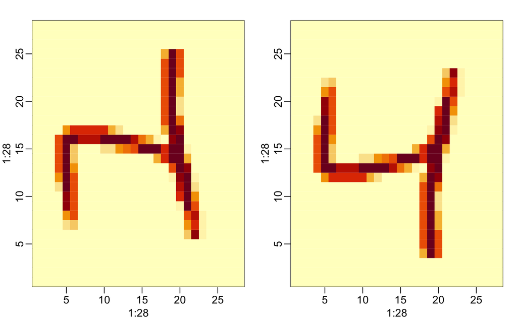

```r
image(1:28, 1:28, grid)
image(1:28, 1:28, grid[, 28:1])
```

## Row and column summaries

- For the first task, related to total pixel darkness, we want to sum the values of each row and then visualize how these values vary by digit.
- The function `rowSums` takes a matrix as input and computes the desired values:

```r
sums <- rowSums(x)
```

## Row and column summaries

- We can also compute the averages with `rowMeans` if we want the values to remain between 0 and 255:

```r
avg <- rowMeans(x)
```

## Row and column summaries

- Once we have this, we can simply generate a boxplot:

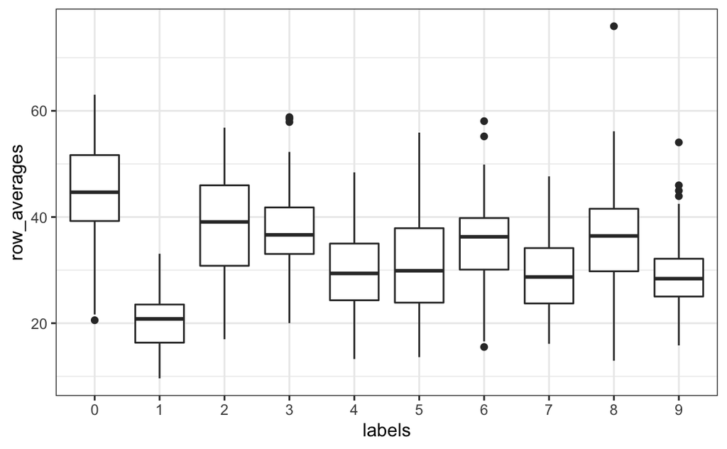

```r
tibble(labels = as.factor(y), row_averages = avg) |>
  qplot(labels, row_averages, data = _, geom = "boxplot")
```

## Row and column summaries

- From this plot we see that, not surprisingly, 1s use less ink than the other digits.
- We can compute the column sums and averages using the function `colSums` and `colMeans`, respectively.
- The **matrixStats** package adds functions that performs operations on each row or column very efficiently, including the functions `rowSds` and `colSds`.

## `apply`

- The functions just described are performing an operation similar to what `sapply` and the **purrr** function `map` do: apply the same function to a part of your object.
- In this case, the function is applied to either each row or each column.
- The `apply` function lets you apply any function, not just `sum` or `mean`, to a matrix.
- The first argument is the matrix, the second is the dimension, 1 for rows, 2 for columns, and the third is the function.

## `apply`

- So, for example, `rowMeans` can be written as:

```r
avgs <- apply(x, 1, mean)
```

- But notice that just like with `sapply` and `map`, we can perform any function.
- So if we wanted the standard deviation for each column, we could write:

```r
sds <- apply(x, 2, sd)
```

- The tradeoff for this flexibility is that these operations are not as fast as dedicated functions such as `rowMeans`.

## Filtering columns based on summaries

- We now turn to task 2: studying the variation of each pixel and removing columns associated with pixels that don’t change much and thus do not inform the classification.
- Although a simplistic approach, we will quantify the variation of each pixel with its standard deviation across all entries.
- Since each column represents a pixel, we use the `colSds` function from the **matrixStats** package:

```r
library(matrixStats)
sds <- colSds(x)
```

## Filtering columns based on summaries

- A quick look at the distribution of these values shows that some pixels have very low entry to entry variability:

```r
qplot(sds, bins = "30", color = I("black"))
```

## Filtering columns based on summaries

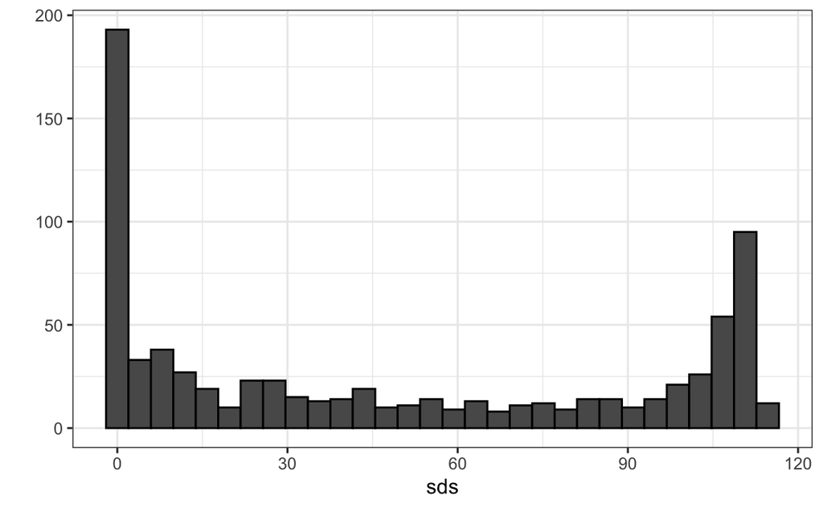

## Filtering columns based on summaries

- This makes sense since we don’t write in some parts of the box.
- Here is the variance plotted by location:

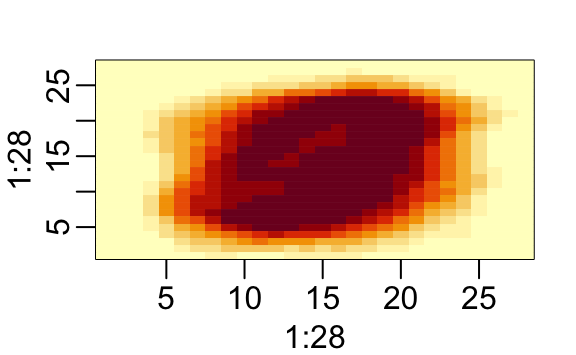

```r
image(1:28, 1:28, matrix(sds, 28, 28)[, 28:1])
```

- We see that there is little variation in the corners.

## Filtering columns based on summaries

- We could remove features that have no variation since these can’t help us predict.
- We can extract columns from matrices using the following code:

```r
x[ ,c(351,352)]
```

- and rows like this:

```r
x[c(2,3),]
```

## Filtering columns based on summaries

- We can also use logical indexes to determine which columns or rows to keep.
- So if we wanted to remove uninformative predictors from our matrix, we could write this one line of code:

```r
new_x <- x[ ,colSds(x) > 60]
dim(new_x)
```

```
#> [1] 1000  314
```

- Only the columns for which the standard deviation is above 60 are kept, which removes over half the predictors.

## Filtering columns based on summaries

- Here we add an important warning related to subsetting matrices: if you select one column or one row, the result is no longer a matrix but a vector.

```r
class(x[,1])
```

```
#> [1] "integer"
```

```r
dim(x[1,])
```

## Filtering columns based on summaries

- However, we can preserve the matrix class by using the argument `drop=FALSE`:

```r
class(x[ , 1, drop=FALSE])
```

```
#> [1] "matrix" "array"
```

```r
dim(x[, 1, drop=FALSE])
```

```
#> [1] 1000    1
```

## Indexing with matrices

```r
mat <- matrix(1:15, 5, 3)
as.vector(mat)
```

```
#>  [1]  1  2  3  4  5  6  7  8  9 10 11 12 13 14 15
```

## Indexing with matrices

- To see a histogram of all our predictor data, we can use:

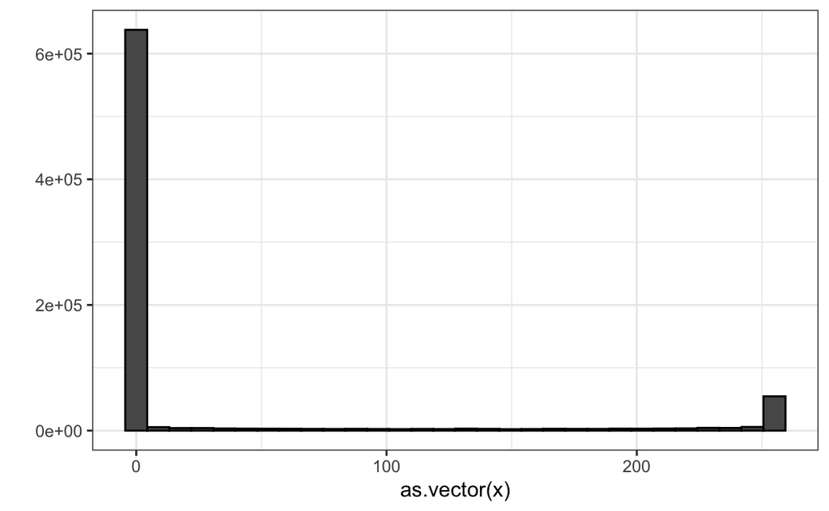

```r
qplot(as.vector(x), bins = 30, color = I("black"))
```

## Indexing with matrices

- We notice a clear dichotomy which is explained as parts of the image with ink and parts without.
- If we think that values below, say, 50 are smudges, we can quickly make them zero using:

```r
new_x <- x
new_x[new_x < 50] <- 0
```

## Indexing with matrices

- To see what this does, we look at a smaller matrix:

```r
mat <- matrix(1:15, 5, 3)
mat[mat < 3] <- 0
mat
```

```
#>      [,1] [,2] [,3]
#> [1,]    0    6   11
#> [2,]    0    7   12
#> [3,]    3    8   13
#> [4,]    4    9   14
#> [5,]    5   10   15
```

## Indexing with matrices

- We can also use logical operations with matrix logical:

```r
mat <- matrix(1:15, 5, 3)
mat[mat > 6 & mat < 12] <- 0
mat
```

```
#>      [,1] [,2] [,3]
#> [1,]    1    6    0
#> [2,]    2    0   12
#> [3,]    3    0   13
#> [4,]    4    0   14
#> [5,]    5    0   15
```

## Binarizing the data

- The histogram above seems to suggest that this data is mostly binary.
- A pixel either has ink or does not.
- Using what we have learned, we can binarize the data using just matrix operations:

```r
bin_x <- x
bin_x[bin_x < 255/2] <- 0
bin_x[bin_x > 255/2] <- 1
```

## Binarizing the data

- We can also convert to a matrix of logicals and then coerce to numbers like this:

```r
bin_X <- (x > 255/2)*1
```

## Binarizing the data

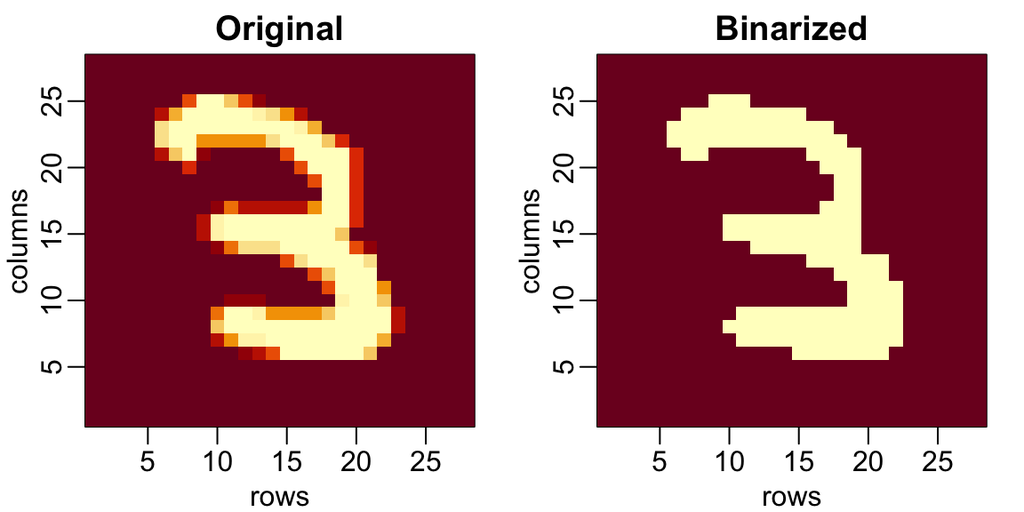

## Vectorization for matrices

- In R, if we subtract a vector from a matrix, the first element of the vector is subtracted from the first row, the second element from the second row, and so on.

## Vectorization for matrices

- Using mathematical notation, we would write it as follows:

\[ \begin{pmatrix} X_{1,1}&\dots & X_{1,p} \\ X_{2,1}&\dots & X_{2,p} \\ & \vdots & \\ X_{N,1}&\dots & X_{N,p} \end{pmatrix} - \begin{pmatrix} a_1\\\ a_2\\\ \vdots\\\ a_N \end{pmatrix} = \begin{pmatrix} X_{1,1}-a_1&\dots & X_{1,p} -a_1\\ X_{2,1}-a_2&\dots & X_{2,p} -a_2\\ & \vdots & \\ X_{N,1}-a_n&\dots & X_{N,p} -a_n \end{pmatrix} \]

## Vectorization for matrices

- The same holds true for other arithmetic operations.
- This implies that we can scale each row of a matrix like this:

```r
(x - rowMeans(x)) / rowSds(x)
```

## Vectorization for matrices

- If you want to scale each column, be careful since this approach does not work for columns.
- To perform a similar operation, we convert the columns to rows using the transpose `t`, proceed as above, and then transpose back:

```r
t(t(X) - colMeans(X))
```

## Vectorization for matrices

- We can also use a function called `sweep` that works similarly to `apply`.
- It takes each entry of a vector and subtracts it from the corresponding row or column.

```r
X_mean_0 <- sweep(x, 2, colMeans(x))
```

## Vectorization for matrices

- The function `sweep` actually has another argument that lets you define the arithmetic operation.
- So to divide by the standard deviation, we do the following:

```r
x_mean_0 <- sweep(x, 2, colMeans(x))
x_standardized <- sweep(x_mean_0, 2, colSds(x), FUN = "/")
```

## Matrix algebra operations

- Finally, although we do not cover matrix algebra operations such as matrix multiplication, we share here the relevant commands for those that know the mathematics and want to learn the code:

1. Matrix multiplication is done with `%*%`. For example, the cross product is:

```r
t(x) %*% x
```

2. We can compute the cross product directly with the function:

```r
crossprod(x)
```

## Matrix algebra operations

3. To compute the inverse of a function, we use `solve`. Here it is applied to the cross product:

```r
solve(crossprod(x))
```

4.The QR decomposition is readily available by using the `qr` function:

```r
qr(x)
```